# Data visualization: Introduction

Gggplot2 (сейчас в версии 3.5) – популярный пакет R для визуализаций в анализе данных https://cran.r-project.org/web/packages/ggplot2/index.html

Расширения ggplot2: https://exts.ggplot2.tidyverse.org/gallery/

Gggplot2 разработан командой Х. Уикхема на основе новой грамматики послойной графики.

- Леланд Уилкинсон. Grammar of Graphics
- Хэдли Уикхэм. A Layered grammar of graphics и пакет `ggplot2`

Каждый график обычно состоит из нескольких **слоев** (layers), которые располагаются один над другим. У каждого слоя есть три обязательных элемента: **данные** (data), **геом** (geom), **эстетики** (aes(tetics))  
и два вспомогательных: **статистические трансформации** (stat) и **регулировка положения** (position adjustment).

- **Данные (data).** Собственно, сами данные в виде датафрейма, используемые в данном слое.
- **Геом (geom).** Геом — это сокращение от “геометрический объект”. Собственно, в какой геометрический объект (графический примитив) мы собираемся превращать данные. Например, в точки, прямоугольники или линии.
- **Отображение (aestetic mappings).** Эстетические отображения или просто **эстетики (aestetics)** — это набор правил, как различные переменные превращаются в визуальные особенности геометрии. Без эстетик остается непонятно, какие именно колонки в используемом датафрейме превращаются в различные особенности геомов: позицию, размер, цвет и т.д. У каждого геома (визуального слоя) свой набор эстетик, но многие из них совпадают у разных геомов (например, *x*, *y*, *colour*, *fill*, *size*) и могут быть заданы в `ggplot()`. Без некоторых эстетик геом не будет работать. Например, геометрия в виде точек не будет работать без двух координат этих точек (*x* и *y*). Другие эстетики необязательны и имеют значения по умолчанию. Например, по умолчанию точки будут черными, но можно сделать их цвет зависимым от выбранной колонки в датафрейме с помощью эстетики *colour*.

[figure not shown]

- **Статистические трансформации (stat).** Название используемой статистической трансформации (или просто — статистики). Обычно те же статистические трансформации можно сделать вне `ggplot2` в рамках препроцессинга данных, но с `ggplot2` бывает удобнее. Формально, статистические трансформации — это обязательный элемент геома, но если вы не хотите преобразовывать данные, то можете выбрать “identity” преобразование, которое оставляет все как есть. В `ggplot2` у каждого геома есть статистика по умолчанию, а у каждой статистики - свой геом по умолчанию. И не всегда статистика по умолчанию — это “identity” статистика. Например, для барплота (`geom_barplot()`) используется статистика “count”, которая считает частоты, которые затем трансформируются в высоту барплотов.
- **Регулировка положения (position adjustment).** Регулировка положения — это небольшое улучшение позиции геометрий для части элементов. Например, можно добавить немного случайного шума (“jitter”) в позицию точек, чтобы они не перекрывали друг друга. Или “раздвинуть” (“dodge”) два барплота, чтобы один не загораживал другой. Как и в случае со статистическими трансформациями, в большинстве случаев значение по умолчанию — “identity”.

Кроме слоев, у графика есть:

- **Координатная система (coord)** – нужна для интерпретации координат. Обычно используется *декартова система координат (Cartesian coordinate system)*, т.е. стандартная прямоугольная система координат, но можно использовать и другие, например, полярную систему координат или картографическую проекцию.
- **Шкалы (scales).** Шкалы задают то, *как именно* значения превращаются в эстетики. Например, если мы задали, что разные значения в колонке будут влиять на цвет точки, то какая именно палитра будет использоваться? В какие конкретно цвета будут превращаться числовые, логические или строковые значения в колонке? В `ggplot2` есть правила по умолчанию для всех эстестик, и они отличные, но самостоятельная настройка шкал может значительно улучшить график.
- **Фасеты (facets).** Фасеты (фасетки) — это одно из нововведений Уикхэма в грамматику графики. Фасетки повзоляют разбить график на множество похожих, задав переменную, по которой график будет разделен. Это очень напоминает использование группировки с помощью `group_by()`.
- **Тема (theme).** Тема — это зрительное оформление “подложки” графика, не относящейся к содержанию графика: размер шрифта, цвет фона, размер и цвет линий на фоне и т.д. и т.п. В `ggplot2` есть несколько встроенных тем, а также есть множество пакетов, которые добавляют дополнительные темы. Кроме того, их можно настраивать самостоятельно!
- **Значения по умолчанию (defaults).** Если в графике используется несколько слоев, то часто все они используют одни и те же данные и эстетики. Можно задать данные и эстетики по умолчанию для всего графика, чтобы не повторять код.

## Пример: пайчарт с распределение по полу

```r
library(tidyverse)
heroes <- read_csv("https://raw.githubusercontent.com/Pozdniakov/tidy_stats/master/data/heroes_information.csv",
                   na = c("-", "-99"))
str(heroes)
```

```
## spc_tbl_ [734 × 11] (S3: spec_tbl_df/tbl_df/tbl/data.frame)
##  $ ...1      : num [1:734] 0 1 2 3 4 5 6 7 8 9 ...
##  $ name      : chr [1:734] "A-Bomb" "Abe Sapien" "Abin Sur" "Abomination" ...
##  $ Gender    : chr [1:734] "Male" "Male" "Male" "Male" ...
##  $ Eye color : chr [1:734] "yellow" "blue" "blue" "green" ...
##  $ Race      : chr [1:734] "Human" "Icthyo Sapien" "Ungaran" "Human / Radiation" ...
##  $ Hair color: chr [1:734] "No Hair" "No Hair" "No Hair" "No Hair" ...
##  $ Height    : num [1:734] 203 191 185 203 NA 193 NA 185 173 178 ...
##  $ Publisher : chr [1:734] "Marvel Comics" "Dark Horse Comics" "DC Comics" "Marvel Comics" ...
##  $ Skin color: chr [1:734] NA "blue" "red" NA ...
##  $ Alignment : chr [1:734] "good" "good" "good" "bad" ...
##  $ Weight    : num [1:734] 441 65 90 441 NA 122 NA 88 61 81 ...
##  - attr(*, "spec")=
##   .. cols(
##   ..   ...1 = col_double(),
##   ..   name = col_character(),
##   ..   Gender = col_character(),
##   ..   `Eye color` = col_character(),
##   ..   Race = col_character(),
##   ..   `Hair color` = col_character(),
##   ..   Height = col_double(),
##   ..   Publisher = col_character(),
##   ..   `Skin color` = col_character(),
##   ..   Alignment = col_character(),
##   ..   Weight = col_double()
##   .. )
##  - attr(*, "problems")=<externalptr>
```

Запустим функцию `ggplot()`, задав наш тиббл `heroes` в качестве данных.

```r
ggplot(data = heroes)
```

Мы ничего не получили! Это естественно, ведь мы задали только данные по умолчанию, но не задали геометрию и эстетики.

Функция `ggplot()` не просто отрисовывает график, эта функция создает объект класса `ggplot`, который можно сохранить и модифицировать в дальнейшем:

```r
almost_empty_ggplot <- ggplot(data = heroes)
almost_empty_ggplot
```

Возьмем `geom_bar()` для отрисовки барплота. В качестве эстетик поставим `x = Gender` и `fill = Gender`. Поскольку это эстетики, они обозначаются внутри функции параметра `mapping = aes()` или просто внутри функции `aes()`. По умолчанию, `geom_bar()` имеет статистику “count”, что нас полностью устраивает: `geom_bar()` сам посчитает табличку частот и использует значения `Gender` для обозначения позиций и заливки, а посчитанные частоты будет использовать для задания высоты столбцов.

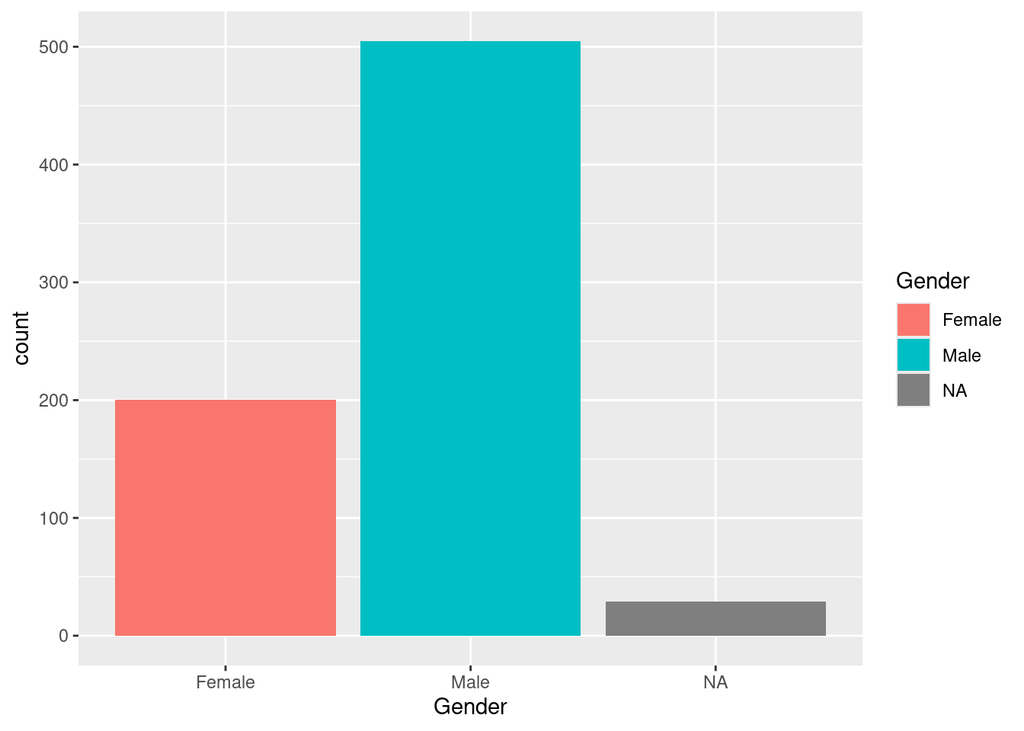

```r
ggplot(data = heroes) +
  geom_bar(aes(x = Gender, fill = Gender))
```

Сейчас мы сделаем один хитрый трюк: поставим значение эстетики `x = ""`, чтобы собрать все столбики в один.

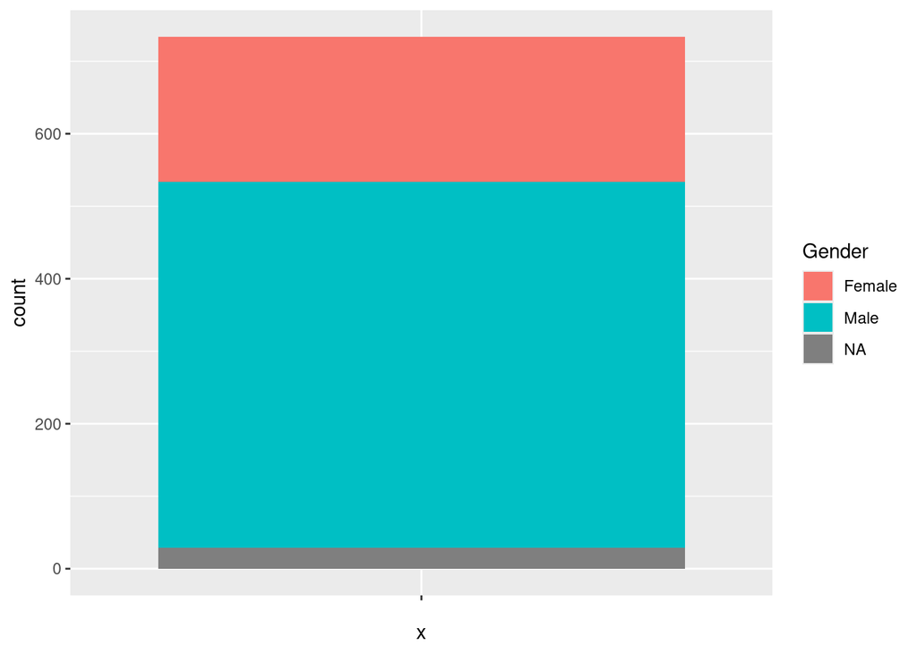

```r
ggplot(data = heroes) +
  geom_bar(aes(x = "", fill = Gender))
```

Получилось что-то не очень симпатичное, но вполне осмысленное: доли столбца обозначают относительную частоту.

Можно настроить общие параметры геома, не зависящие от данных. Это нужно делать *вне* функции `aes()`, но внутри функции для геома.

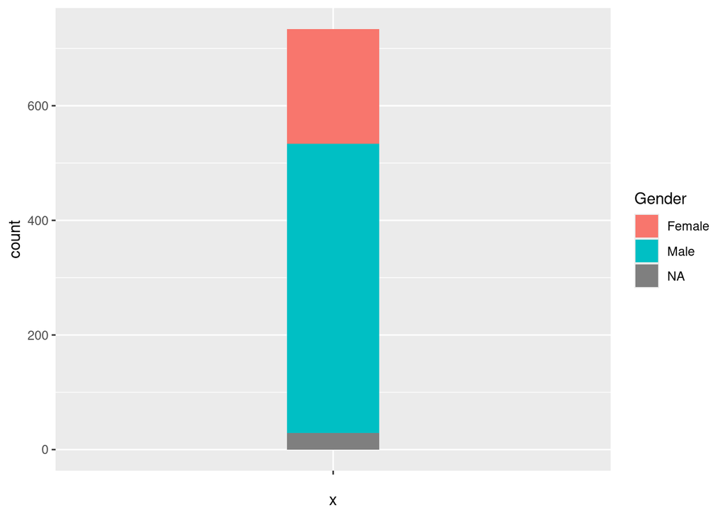

```r
ggplot(data = heroes) +
  geom_bar(aes(x = "", fill = Gender), width = .2)
```

А теперь внимание! Подумайте, какого действия нам не хватает, чтобы из имеющегося графика получить пайчарт?

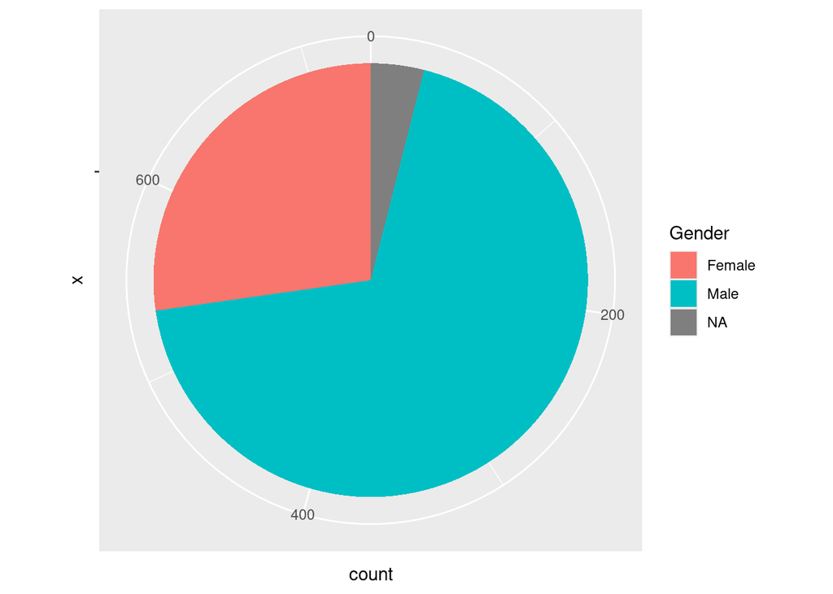

```r
ggplot(data = heroes) +
  geom_bar(aes(x = "", fill = Gender)) +
  coord_polar(theta = "y")
```

```r
# уберите theta = "y", чтобы понять, что она делает
```

Нам нужно было всего-лишь поменять систему координат с декартовой на полярную (круговую)! Иначе говоря, пайчарт - это барплот в полярной системе координат.

Именно в этом основная сила грамматики графики и ее реализации в `ggplot2` — вместо того, чтобы описывать и рисовать огромное количество типов графиков, можно описать практически любой график через небольшой количество элементарных элементов и правила их соединения.

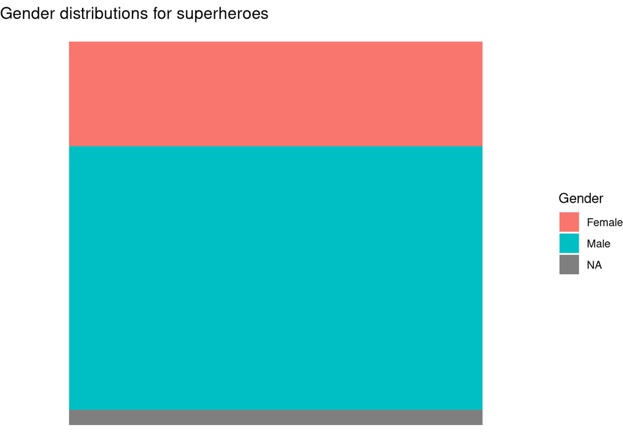

[output not shown]

```r
ggplot(data = heroes) +
  geom_bar(aes(x = "", fill = Gender)) +
  #coord_polar(theta = "y") +
  theme_void() +
  labs(title = "Gender distributions for superheroes")
```

## Пример №1: Education and IQ meta-analysis

Для этого примера мы возьмем мета-анализ связи количества лет обучения и интеллекта: *“How Much Does Education Improve Intelligence? A Meta-Analysis”* [@eduiq]. Мета-анализ — это группа статистических методов, которые позволяют объединить результаты нескольких исследований с похожим планом исследованием и тематикой, чтобы посчитать средний эффект между несколькими статьями сразу.

Данные и скрипт для анализа данных в этой статье находятся в открытом доступе: https://osf.io/r8a24/

Полный текст статьи доступен по [ссылке](https://www.ncbi.nlm.nih.gov/pmc/articles/PMC6088505/).

Существует положительная корреляция между количеством лет, который человек потратил на обучение, и интеллектом. Это может объясняться по-разному: как то, что обучение повышает интеллект, и как то, что люди с высоким интеллекте стремятся получать больше образования. Напрямую в эксперименте это проверить нельзя, поэтому есть несколько квази-экспериментальных планов, которые косвенно указывают на верность той или иной гипотезу. Например, если в стране изменилось количество лет обязательного школьного образования, то повлияло ли это на интеллект целого поколения? Или все-таки дело в Моргенштерне

[figure not shown]

Данная картинка показывает, насколько размер эффекта (выраженный в баллах IQ) зависит от того, какой средний возраст участвоваших в исследовании испытуемых.

Каждая точка на этом графике — это отдельное исследование, положение по оси *x* — средний возраст респондентов, а положение по оси *y* - средний прирост интеллекта согласно исследованию. Размер точки отражает “точность” исследования (грубо говоря, чем больше выборка, тем больше точка). Два графика обозначают два квазиэкспериментальных плана.

Мы сфокусируемся на нижней картинке с “Policy change” — это как раз исследования, в которых изучается изменения интеллекта в возрастных группах после изменения количества лет обучения в школе.

[figure not shown]

Мы полностью воспроизведем код

```r
library(tidyverse)
```

Заметьте, данный датасет использует формат хранения данных tsv. Попытайтесь самостоятельно прочитать его.

```r
df <- read_tsv("https://raw.githubusercontent.com/Pozdniakov/tidy_stats/master/data/meta_dataset.txt")
```

Давайте посмотрим, как устроен датафрейм `df`:

```r
df
```

```
## # A tibble: 142 × 17
##    Study_ID Data_ID     k Country     n Design      outcome_test_cat Effect_size
##       <dbl>   <dbl> <dbl> <chr>   <dbl> <chr>                  <dbl>       <dbl>
##  1      1         1     4 UK        483 Control Pr…                0     0.778
##  2      1         1     4 UK        290 Control Pr…                1     0.0771
##  3      1         1     4 UK        290 Control Pr…                1     0.427
##  4      1         1     4 UK        288 Control Pr…                1     0.00519
##  5      1         2    13 UK       1017 Control Pr…                0     1.62
##  6      1         2    13 UK       1022 Control Pr…                1     0.915
##  7      1         2    13 UK       1021 Control Pr…                1     0.305
##  8      1         2    13 UK        981 Control Pr…                1     0.719
##  9      1.5       2    13 UK       1024 Control Pr…                1     1.70
## 10      1.5       2    13 UK       1023 Control Pr…                1     1.78
## # ℹ 132 more rows
## # ℹ 9 more variables: SE <dbl>, Outcome_age <dbl>, quasi_age <dbl>,
## #   cpiq_early_age <dbl>, cpiq_age_diff <dbl>, ses_funnel <dbl>,
## #   published <dbl>, Male_only <dbl>, Achievement <dbl>
```

Каждая строчка — это результат отдельного исследования, при этом одна статья может включать несколько исследований,

В дальнейшем мы будем использовать код авторов статьи и смотреть, строчка за строчкой, как он будет работать.

```r
cpiq <- subset(df, subset=(Design=="Control Prior IQ"))
poli <- subset(df, subset=(Design=="Policy Change"))
```

Авторы исследования используют `subset()`, это функция базового R, принцип которой очень похож на `filter()` [^1].

Итак, начнем рисовать сам график. Сначала иницируем объект `ggplot` с данными `poli` по умолчанию.

```r
poli |>
  ggplot()
```

Теперь добавим в качестве эстетик по умолчанию координаты: `aes(x=Outcome_age, y=Effect_size)`.

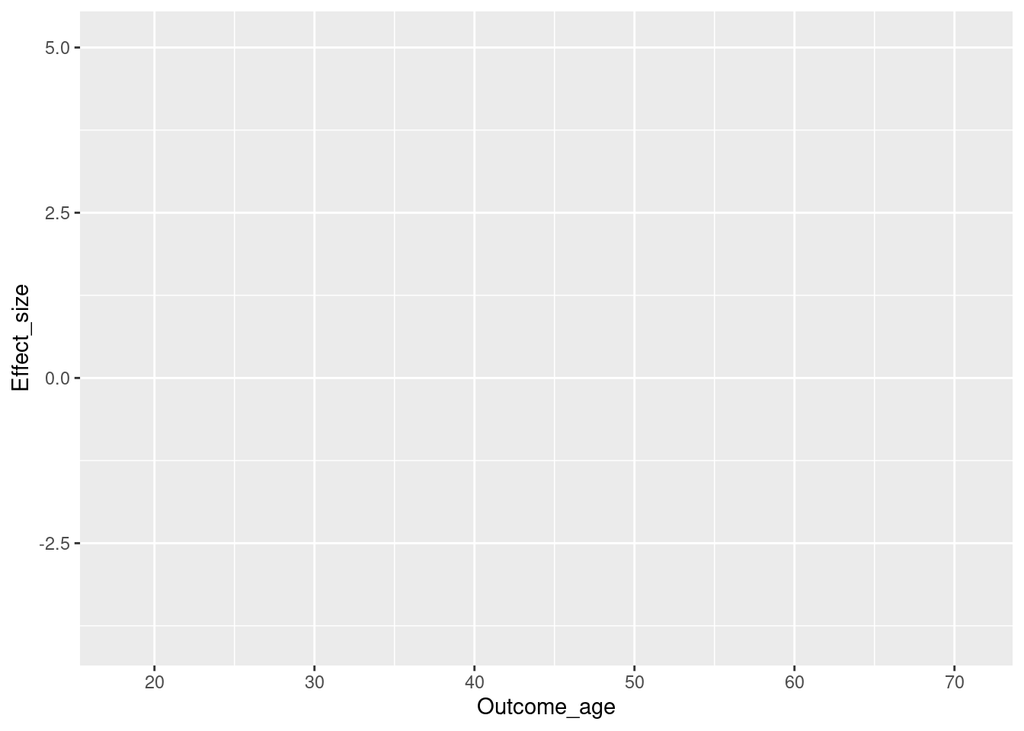

```r
cpiq <- subset(df, subset=(Design=="Control Prior IQ"))
poli <- subset(df, subset=(Design=="Policy Change"))

poli |>
  ggplot(aes(x=Outcome_age, y=Effect_size))
```

Что изменилось? Появилась координатная ось и шкалы. Заметьте, масштаб неслучаен: он строится на основе разброса значений в выбранных колонках. Однако этого недостаточно для отрисовки графика, нехватает геометрии: нужно задать, в какую географическую сущность отобразятся данные.

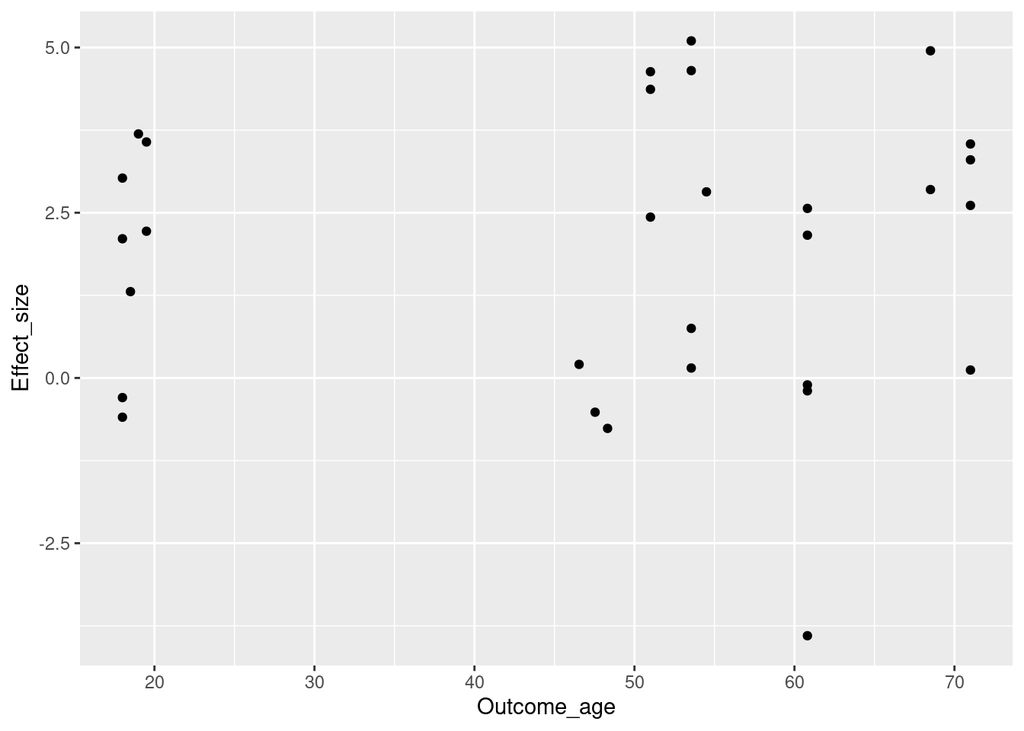

```r
ggplot(aes(x=Outcome_age, y=Effect_size), data=poli) +
        geom_point()
```

Готово! Это и есть основа картинки. Добавляем размер:

```r
poli
```

```
## # A tibble: 30 × 17
##    Study_ID Data_ID     k Country      n Design     outcome_test_cat Effect_size
##       <dbl>   <dbl> <dbl> <chr>    <dbl> <chr>                 <dbl>       <dbl>
##  1        5       8     1 Sweden  142221 Policy Ch…                0        1.31
##  2        6       9     1 Norway  107223 Policy Ch…                0        3.69
##  3        7      10     2 USA      11427 Policy Ch…                1        4.95
##  4        7      10     2 USA      11427 Policy Ch…                1        2.85
##  5        9      12     4 UK        2385 Policy Ch…                1        5.1
##  6        9      12     4 UK        2057 Policy Ch…                1        4.65
##  7        9      12     4 UK        1963 Policy Ch…                1        0.15
##  8        9      12     4 UK        1701 Policy Ch…                1        0.75
##  9       10      13     2 UK        1860 Policy Ch…                1        2.61
## 10       10      13     2 UK        1860 Policy Ch…                1        3.54
## # ℹ 20 more rows
## # ℹ 9 more variables: SE <dbl>, Outcome_age <dbl>, quasi_age <dbl>,
## #   cpiq_early_age <dbl>, cpiq_age_diff <dbl>, ses_funnel <dbl>,
## #   published <dbl>, Male_only <dbl>, Achievement <dbl>
```

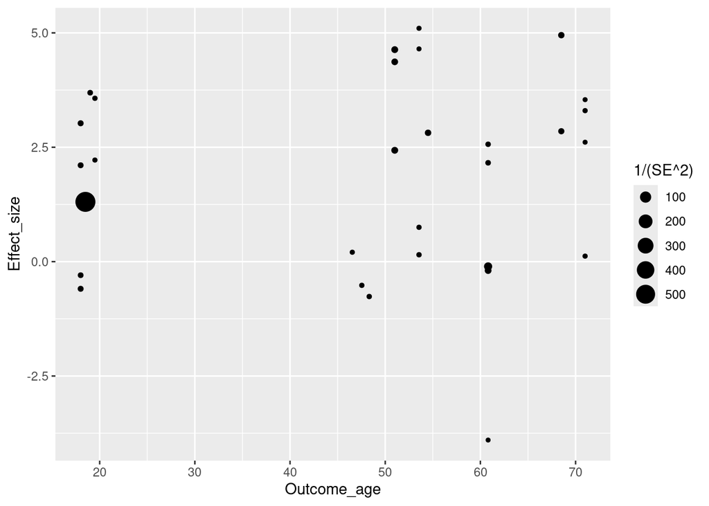

```r
ggplot(aes(x=Outcome_age, y=Effect_size, size=1/(SE^2)), data=poli) +
        geom_point()
```

Перед нами возникла проблема оверплоттинга: некоторые точки перекрывают друг друга, поскольку имеют очень близкие координат. Авторы графика решают эту проблему очевидным способом: добавляют прозрачности точкам. Заметьте, прозрачность задается для всех точек одним значением, поэтому параметр `alpha` задается вне функции `aes()`.

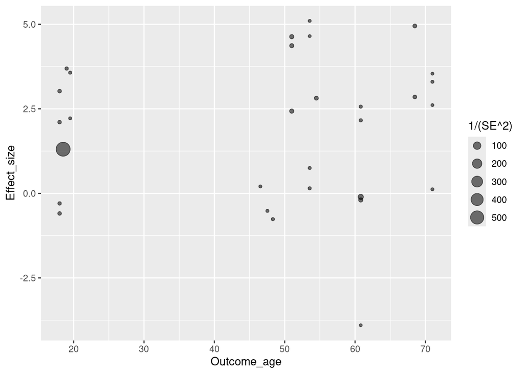

```r
ggplot(aes(x=Outcome_age, y=Effect_size, size=1/(SE^2)), data=poli) +
        geom_point(alpha=.55)
```

Совершенно так же задается и цвет. Он задается одинаковым для всех точек с помощью [HEX-кода](https://ru.wikipedia.org/wiki/Цвета_HTML).

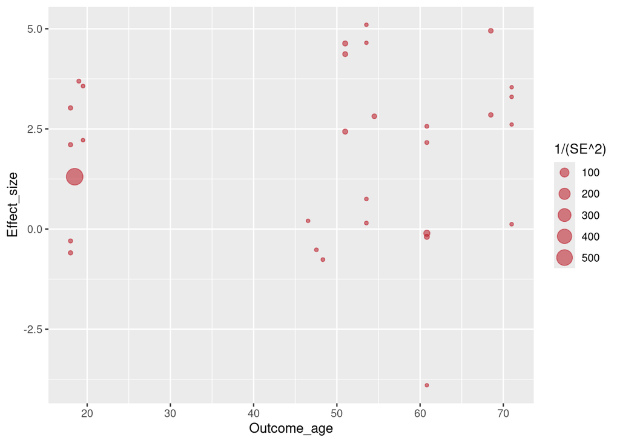

```r
ggplot(aes(x=Outcome_age, y=Effect_size, size=1/(SE^2)), data=poli) +
        geom_point(alpha=.55, colour="#BA1825")
```

Теперь добавим регрессионную прямую с доверительными интервалами на график. Это специальный геом `geom_smooth()` со специальной статистикой, который займет второй слой данного графика.

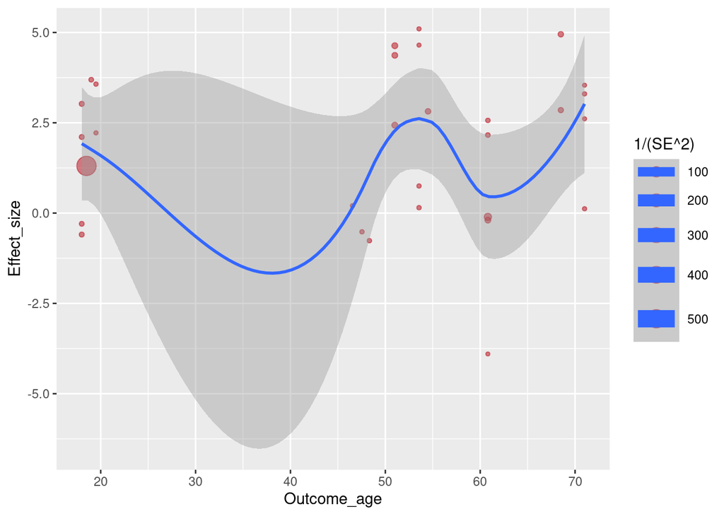

```r
ggplot(aes(x=Outcome_age, y=Effect_size, size=1/(SE^2)), data=poli) +
        geom_point(alpha=.55, colour="#BA1825") +
        geom_smooth()
```

По умолчанию `geom_smooth()` строит кривую линию. Поставим `method = "lm"` для прямой.

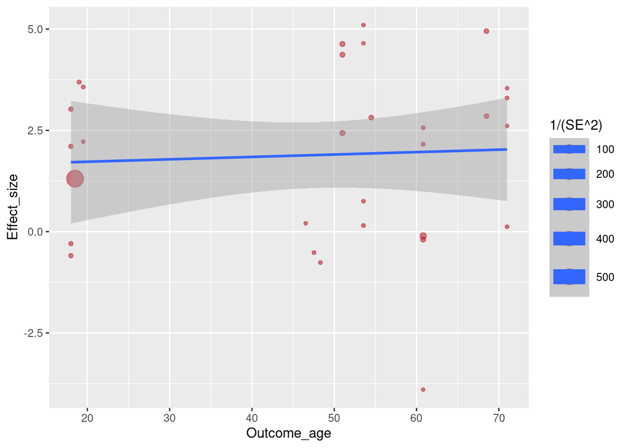

```r
ggplot(aes(x=Outcome_age, y=Effect_size, size=1/(SE^2)), data=poli) +
        geom_point(alpha=.55, colour="#BA1825") +
        geom_smooth(method="lm")
```

Теперь нужно поменять цвет: ярко синий цвет, используемый по умолчанию здесь попросту мешает восприятию графика.

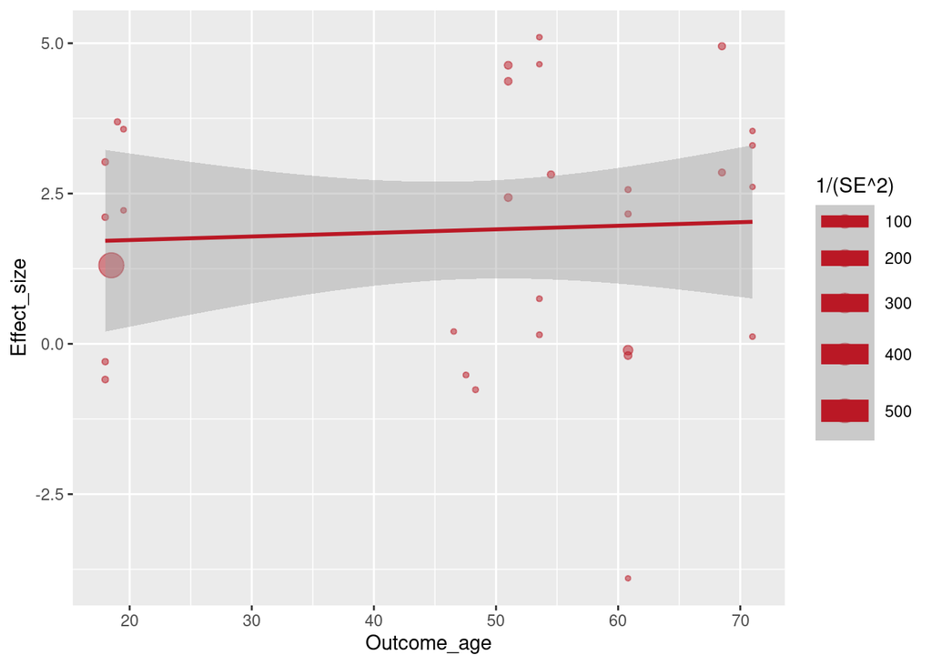

```r
ggplot(aes(x=Outcome_age, y=Effect_size, size=1/(SE^2)), data=poli) +
        geom_point(alpha=.5, colour="#BA1825") +
        geom_smooth(method="lm", colour="#BA1825")
```

Авторы графика перекрашивают серую полупрозначную область тоже. В этом случае используется параметр `fill =`, а не `colour =`, но цвет используется тот же.

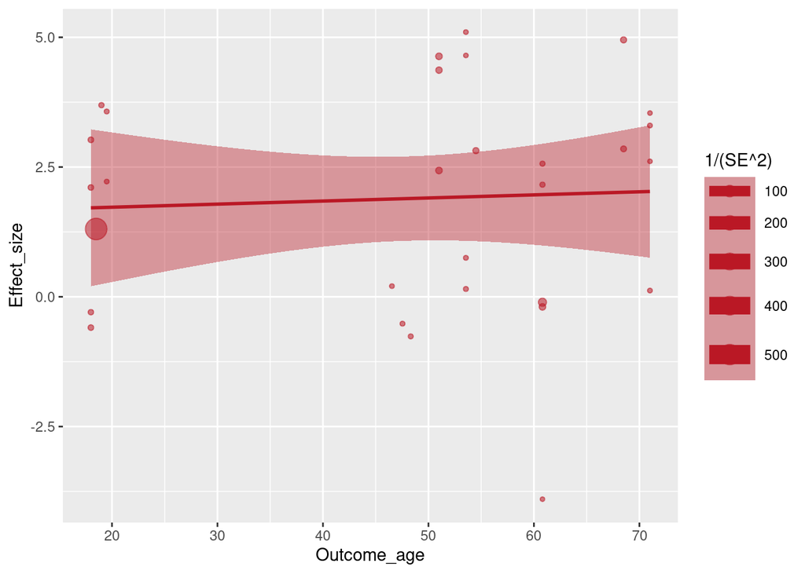

```r
ggplot(aes(x=Outcome_age, y=Effect_size, size=1/(SE^2)), data=poli) +
        geom_point(colour="#BA1825", alpha=.55) +
        geom_smooth(method="lm", colour="#BA1825", fill="#BA1825")
```

Регрессионную линию авторы немного утоньшают с помощью параметра `size =`.

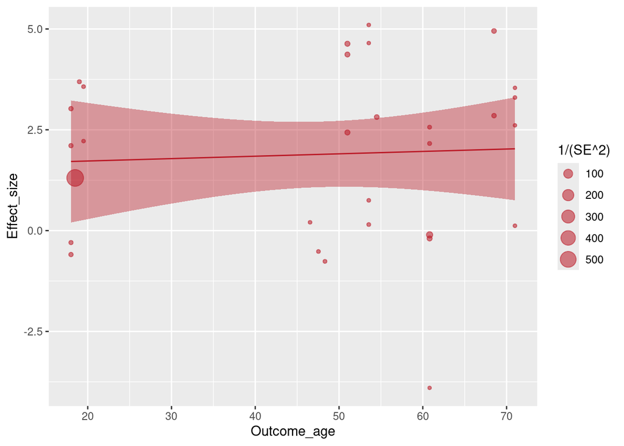

```r
ggplot(aes(x=Outcome_age, y=Effect_size, size=1/(SE^2)), data=poli) +
        geom_point(alpha=.55, colour="#BA1825") +
        geom_smooth(method="lm", colour="#BA1825",fill="#BA1825", size=.5)
```

Чтобы сместить фокус в сторону точек, авторы добавляют прозрачности для всего `geom_smooth()`.

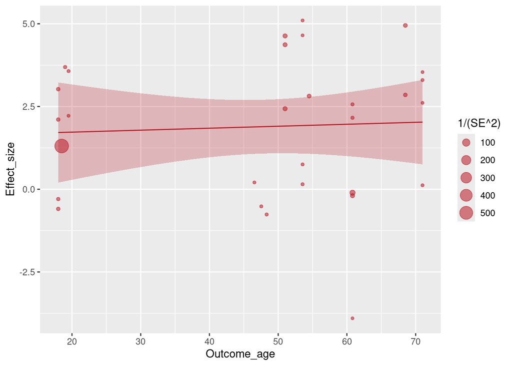

```r
ggplot(aes(x=Outcome_age, y=Effect_size, size=1/(SE^2)), data=poli) +
        geom_point(alpha=.55, colour="#BA1825") +
        geom_smooth(method="lm", colour="#BA1825",fill="#BA1825",size=.5, alpha=.25)
```

На шкале присутствует 0, и по умолчанию он никак не обозначен. Это легко исправить с помощью вспомогательного геома `geom_hline()`.

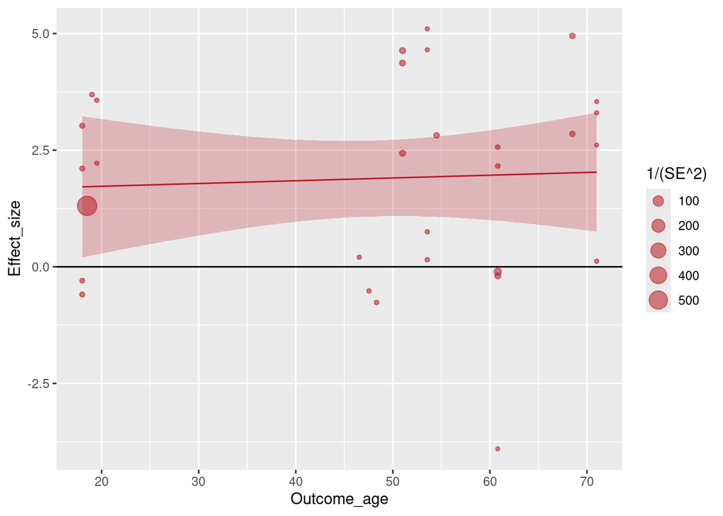

```r
ggplot(aes(x=Outcome_age, y=Effect_size, size=1/(SE^2)), data=poli) +
        geom_point(alpha=.55, colour="#BA1825") +
        geom_hline(yintercept=0) +
        geom_smooth(method="lm", colour="#BA1825",fill="#BA1825",size=.5, alpha=.25)
```

Оттенить эту линию можно, сделав ее пунктирной.

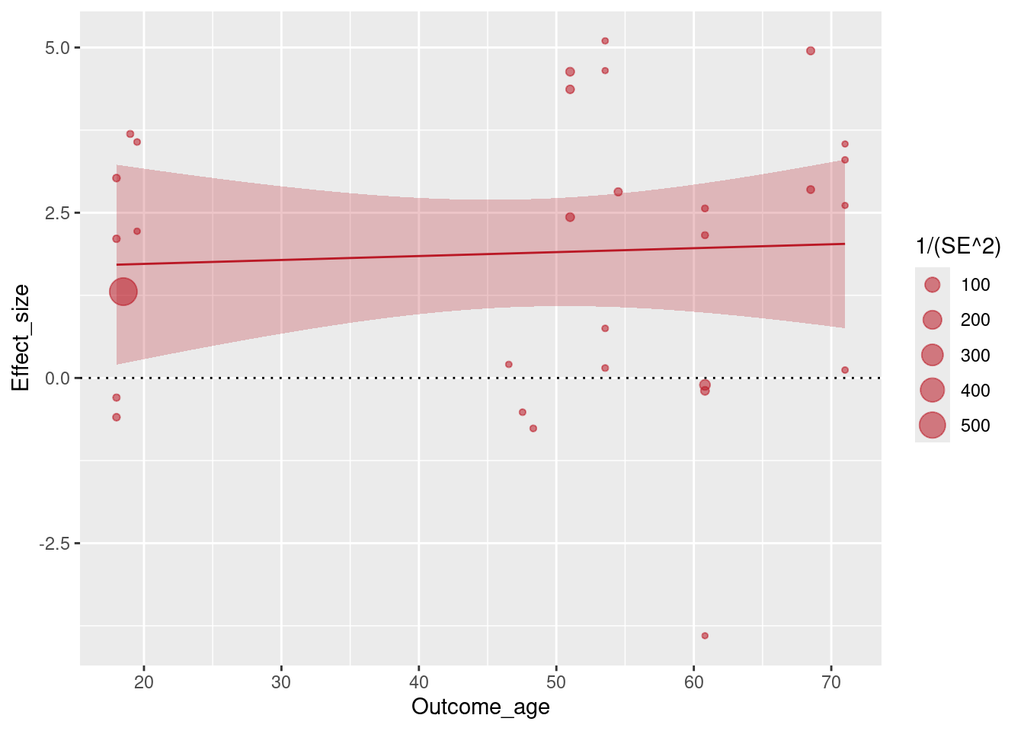

```r
ggplot(aes(x=Outcome_age, y=Effect_size, size=1/(SE^2)), data=poli) +
        geom_point(alpha=.55, colour="#BA1825") +
        geom_hline(yintercept=0, linetype="dotted") +
        geom_smooth(method="lm", colour="#BA1825",fill="#BA1825",size=.5, alpha=.25)
```

Авторы графика вручную задают деления шкалы по оси *x*.

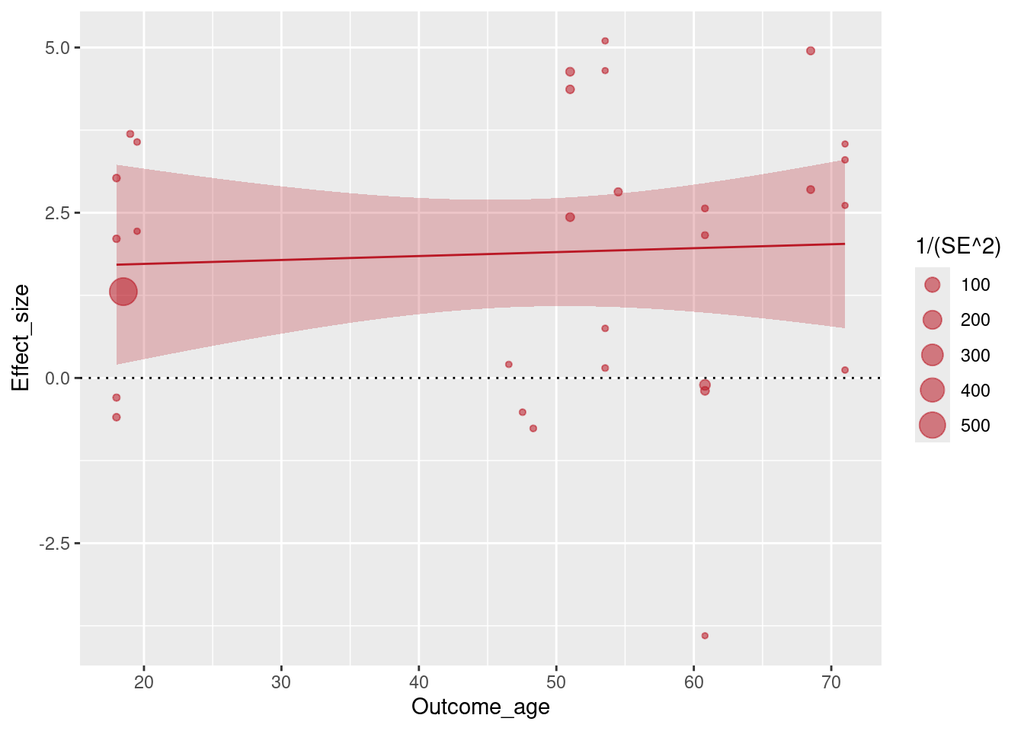

```r
ggplot(aes(x=Outcome_age, y=Effect_size, size=1/(SE^2)), data=poli) +
        geom_point(alpha=.55, colour="#BA1825") +
        geom_hline(yintercept=0, linetype="dotted") +
        scale_x_continuous(breaks=c(20,30,40,50,60,70,80)) +
        geom_smooth(method="lm", colour="#BA1825",fill="#BA1825",size=.5, alpha=.25)
```

С помощью функции `guides()` убирают легенду с картинки.

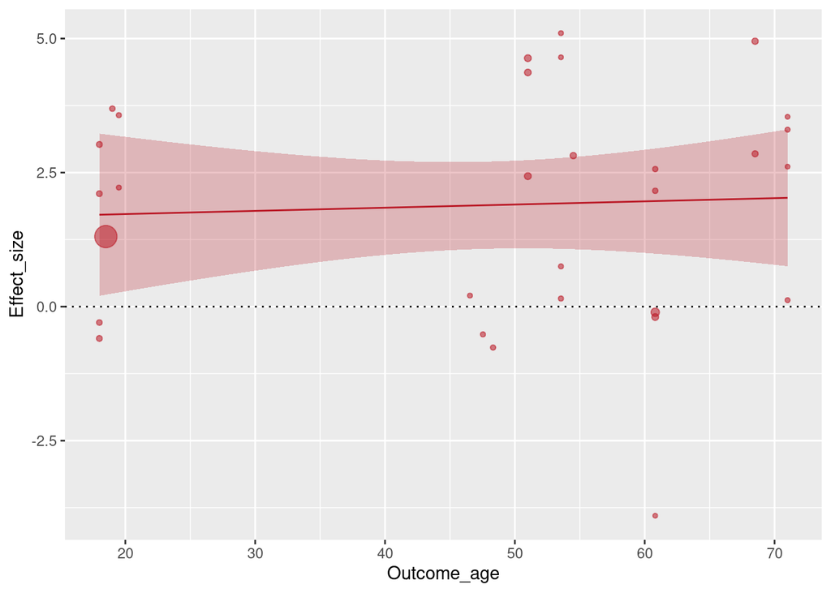

```r
ggplot(aes(x=Outcome_age, y=Effect_size, size=1/(SE^2)), data=poli) +
        geom_point(alpha=.55, colour="#BA1825") +
        geom_hline(yintercept=0, linetype="dotted") +
        scale_x_continuous(breaks=c(20,30,40,50,60,70,80)) +
        guides(size=F) +
        geom_smooth(method="lm", colour="#BA1825",fill="#BA1825",size=.5, alpha=.25)
```

Следующим этапом авторы добавляют подписи шкал и название картинки. Обратите внимание на `\n` внутри подписи к оси *y*, которая задает перенос на следующую строку.

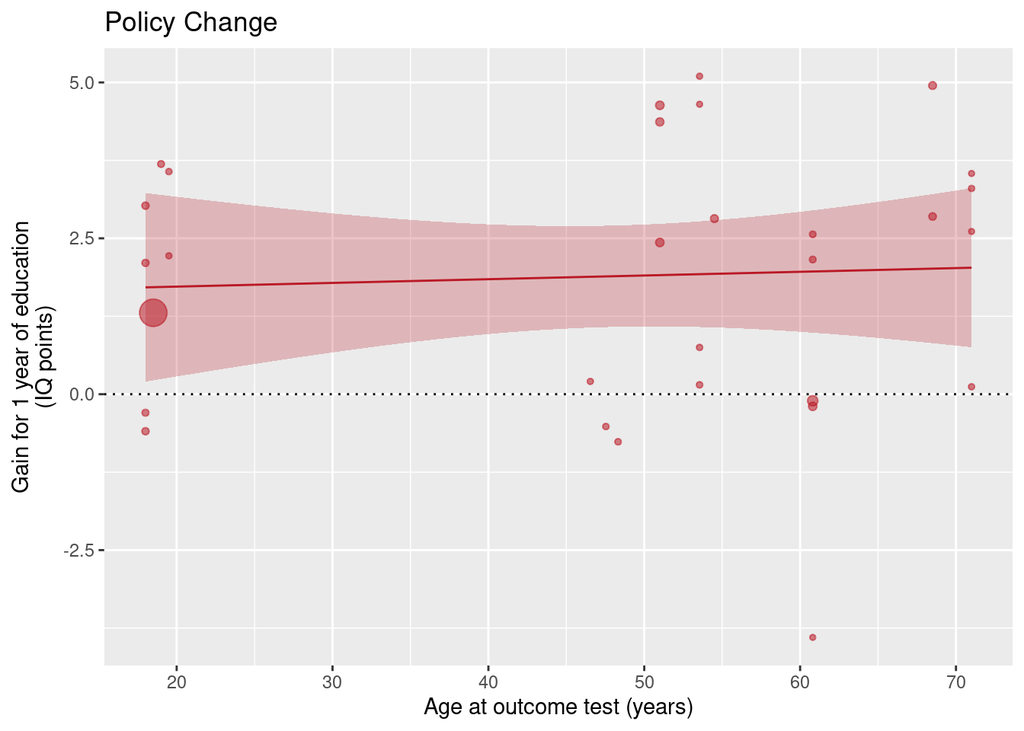

```r
ggplot(aes(x=Outcome_age, y=Effect_size, size=1/(SE^2)), data=poli) +
        geom_point(alpha=.55, colour="#BA1825") +
        geom_hline(yintercept=0, linetype="dotted") +
        scale_x_continuous(breaks=c(20,30,40,50,60,70,80)) +
        xlab("Age at outcome test (years)") +
        ylab("Gain for 1 year of education\n(IQ points)") +
        guides(size=F) +
        geom_smooth(method="lm", colour="#BA1825",fill="#BA1825",size=.5, alpha=.25) +
    ggtitle("Policy Change")
```

Теперь пришло время сделать график более красивым и понятным с помощью изменения подложки, т.е. работы с темой графика. Здесь тема задается сначала как `theme_bw()` — встроенная в `ggplot2` минималистичная тема, а потом через функцию `theme()`, через которую можно управлять конкретными элементами темы. Здесь это сделано, чтобы передвинуть название графика к центру.

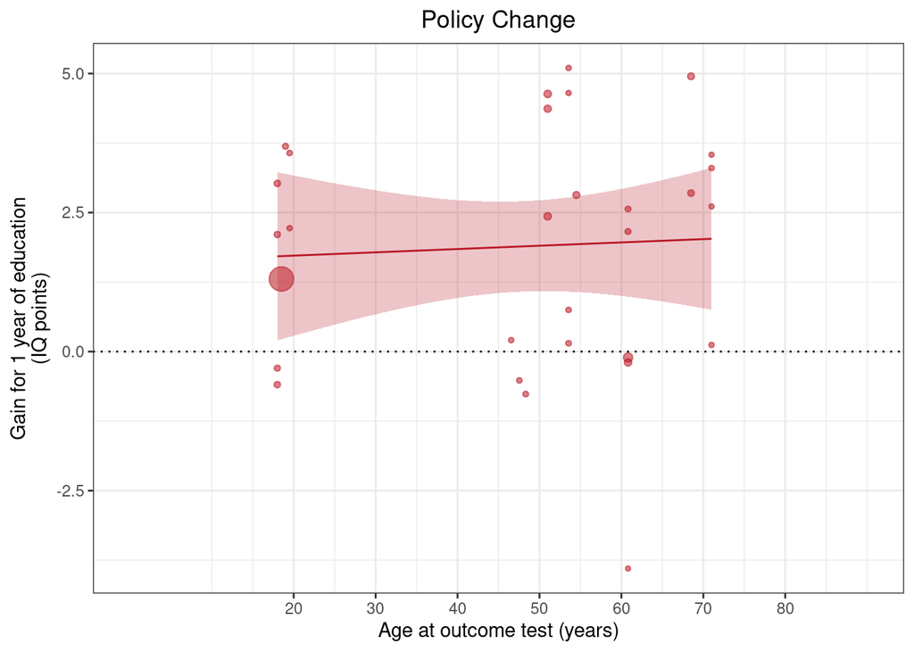

```r
ggplot(aes(x=Outcome_age, y=Effect_size, size=1/(SE^2)), data=poli) +
        geom_point(alpha=.55, colour="#BA1825") +
        geom_hline(yintercept=0, linetype="dotted") +
        theme_bw() +
        scale_x_continuous(breaks=c(20,30,40,50,60,70,80), limits = c(0, 90)) +
        xlab("Age at outcome test (years)") +
        ylab("Gain for 1 year of education\n(IQ points)") +
        guides(size=F) +
        geom_smooth(method="lm", colour="#BA1825",fill="#BA1825",size=.5, alpha=.25) +
    ggtitle("Policy Change") +
        theme(plot.title = element_text(hjust=0.5))
```

Готово! Мы полностью воспроизвели график авторов статьи с помощью их открытого кода.

Если вы помните, то в изначальном графике было две картинки. Авторы делают их отдельно, с помощью почти идентичного кода. Нечто похожее можно сделать по-другому, применяя фасетки.

Для этого мы возьмем неотфильтрованный датасет `df`, а с помощью колонки `Design`, на основании которой разделялся датасет для графиков, произведем разделение графиков внутри самого `ggplot` объекта. Для этого нам понадобится функция `facet_wrap()`, в которой с помощью формулы можно задать колонки, по которым будут разделены картинки по вертикали (слева от ~) и горизонтально (справа от ~). Пробуем разделить графики горизонтально:

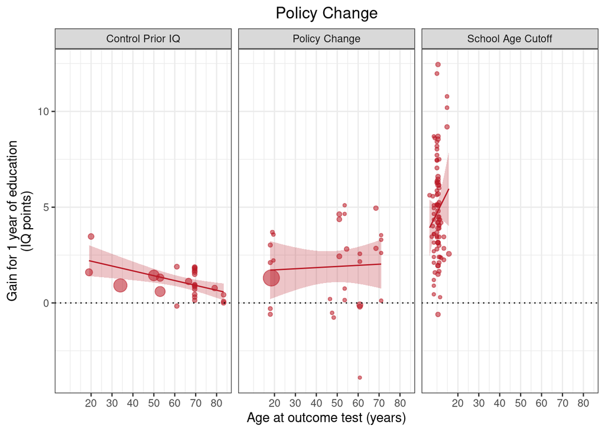

```r
ggplot(aes(x=Outcome_age, y=Effect_size, size=1/(SE^2)), data=df) +
        geom_point(alpha=.55, colour="#BA1825") +
        geom_hline(yintercept=0, linetype="dotted") +
        theme_bw() +
        scale_x_continuous(breaks=c(20,30,40,50,60,70,80)) +
        xlab("Age at outcome test (years)") +
        ylab("Gain for 1 year of education\n(IQ points)") +
        guides(size=F) +
        geom_smooth(method="lm", colour="#BA1825",fill="#BA1825",size=.5, alpha=.25) + ggtitle("Policy Change")+
        theme(plot.title = element_text(hjust=0.5)) +
    facet_wrap(~Design)
```

Здесь становится очевидно, почему авторы не включали данные `"School Age Cutoff"` третьим графиком: средний возраст участников этих исследований сильно отличается.

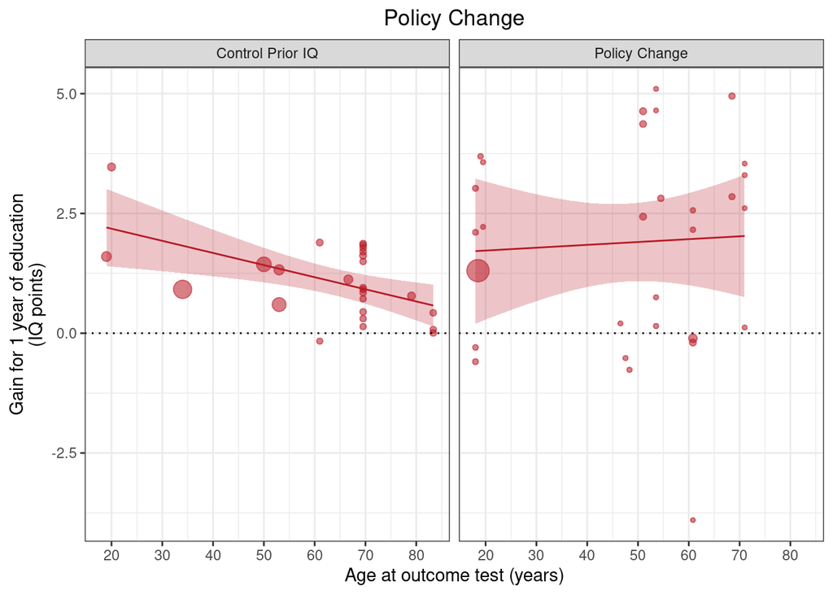

```r
ggplot(aes(x=Outcome_age, y=Effect_size, size=1/(SE^2)),
       data=df |>
         filter(Design != "School Age Cutoff")) +
        geom_point(alpha=.55, colour="#BA1825") +
        geom_hline(yintercept=0, linetype="dotted") +
        theme_bw() +
        scale_x_continuous(breaks=c(20,30,40,50,60,70,80)) +
        xlab("Age at outcome test (years)") +
        ylab("Gain for 1 year of education\n(IQ points)") +
        guides(size=F) +
        geom_smooth(method="lm", colour="#BA1825",fill="#BA1825",size=.5, alpha=.25) + ggtitle("Policy Change")+
        theme(plot.title = element_text(hjust=0.5)) +
    facet_wrap(~Design)
```

## facet_grid

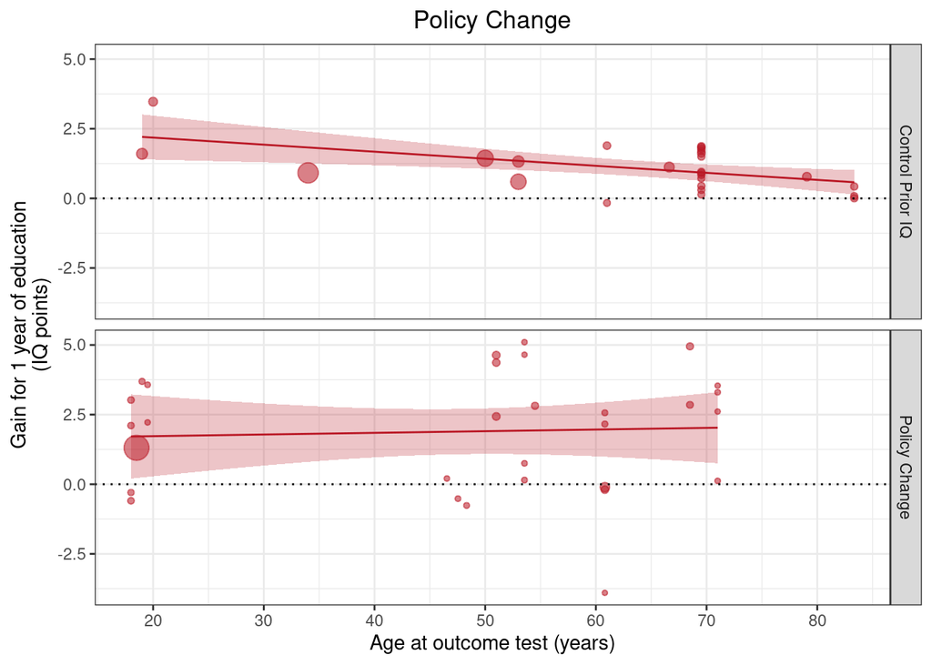

```r
ggplot(aes(x=Outcome_age, y=Effect_size, size=1/(SE^2)), data=df |> filter(Design != "School Age Cutoff")) +
        geom_point(alpha=.55, colour="#BA1825") +
        geom_hline(yintercept=0, linetype="dotted") +
        theme_bw() +
        scale_x_continuous(breaks=c(20,30,40,50,60,70,80)) +
        xlab("Age at outcome test (years)") +
        ylab("Gain for 1 year of education\n(IQ points)") +
        guides(size=F) +
        geom_smooth(method="lm", colour="#BA1825",fill="#BA1825",size=.5, alpha=.25) + ggtitle("Policy Change")+
        theme(plot.title = element_text(hjust=0.5)) +
    facet_grid(Design~.)
```

Теперь нужно изменить подписи.

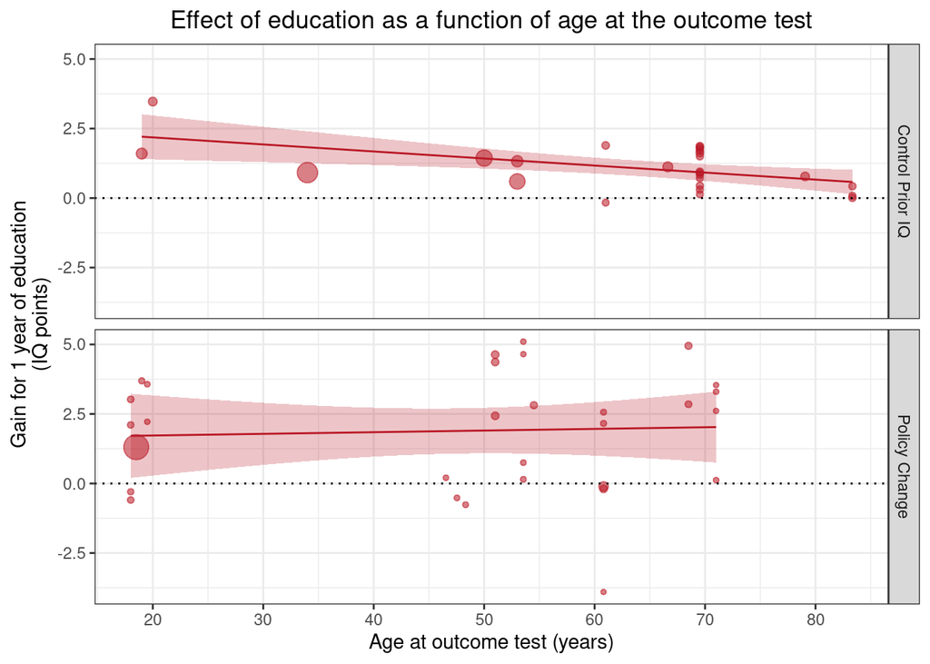

```r
ggplot(aes(x=Outcome_age, y=Effect_size, size=1/(SE^2)), data=df |> filter(Design != "School Age Cutoff")) +
        geom_point(alpha=.55, colour="#BA1825") +
        geom_hline(yintercept=0, linetype="dotted") +
        theme_bw() +
        scale_x_continuous(breaks=c(20,30,40,50,60,70,80)) +
        xlab("Age at outcome test (years)") +
        ylab("Gain for 1 year of education\n(IQ points)") +
        guides(size=F) +
        geom_smooth(method="lm", colour="#BA1825",fill="#BA1825",size=.5, alpha=.25) +
    ggtitle("Effect of education as a function of age at the outcome test")+
        theme(plot.title = element_text(hjust=0.5)) +
    facet_grid(Design~.)
```

Чтобы акцентировать графики, можно раскрасить их в разные цвета в дополнение к фасеткам. Для этого мы переносим `colour =` и `fill =` из параметров соответствующих геомов внутрь эстетик и делаем зависимыми от `Design`. Поскольку эти эстетики (точнее, `colour =`) одинаковы заданы для двух геомов (`geom_point()` и `geom_smooth()`), то мы спокойно можем вынести их в эстетики по умолчанию — в параметры `aes()` внутри `ggplot()`.

При этом сразу выключим легенды для новых эстетик, потому они избыточны.

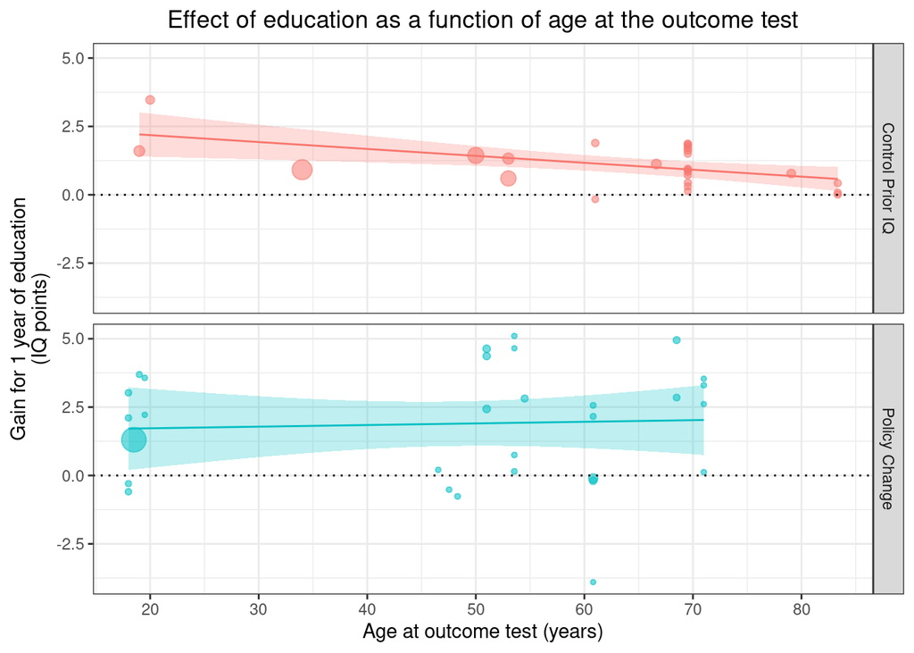

```r
ggplot(aes(x=Outcome_age, y=Effect_size, size=1/(SE^2), colour = Design, fill = Design), data=df |> filter(Design != "School Age Cutoff")) +
        geom_point(alpha=.55) +
        geom_hline(yintercept=0, linetype="dotted") +
        theme_bw() +
        scale_x_continuous(breaks=c(20,30,40,50,60,70,80)) +
        xlab("Age at outcome test (years)") +
        ylab("Gain for 1 year of education\n(IQ points)") +
        guides(size=FALSE, colour = FALSE, fill = FALSE) +
        geom_smooth(method="lm", size=.5, alpha=.25) +
    ggtitle("Effect of education as a function of age at the outcome test")+
        theme(plot.title = element_text(hjust=0.5)) +
    facet_grid(Design~.)
```

Слишком блеклая палитра? Не беда, можно задать палитру вручную! В `ggplot2` встроены легендарные *Brewer’s Color Palettes*, которыми мы и воспользуемся.

Функции для шкал устроены интересным образом: они состоят из трех слов, первое из которых `scale_*_*()`, второе — эстетика, например, `scale_color_*()`, а последнее слово — тип самой шкалы, в некоторых случаях - специальное название для используемой шкалы, как и в случае с `scale_color_brewer()`.

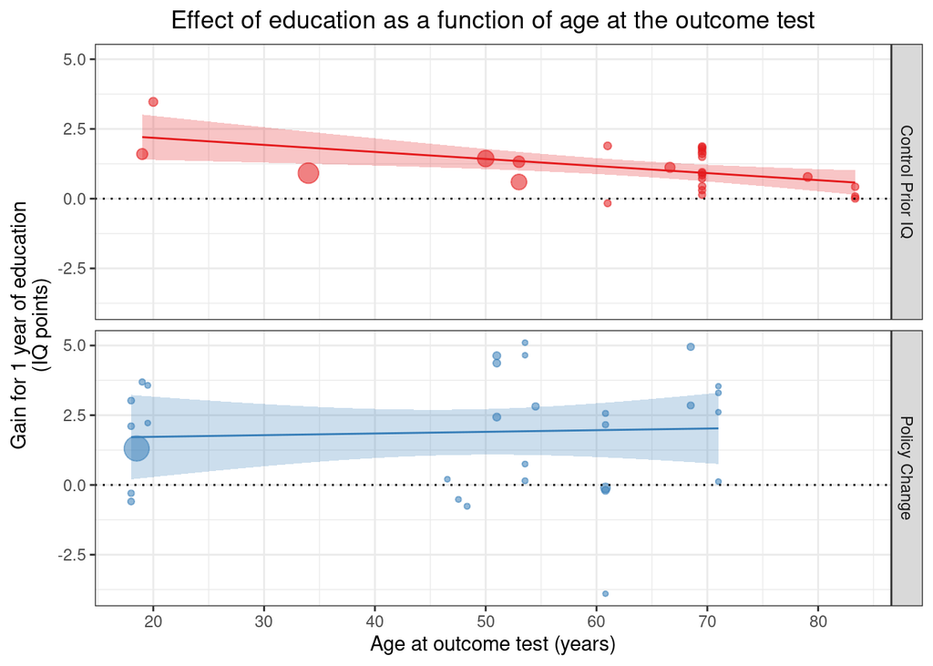

```r
meta_2_gg <- ggplot(aes(x=Outcome_age, y=Effect_size, size=1/(SE^2), colour = Design, fill = Design), data=df |> filter(Design != "School Age Cutoff")) +
        geom_point(alpha=.55) +
        geom_hline(yintercept=0, linetype="dotted") +
        theme_bw() +
        scale_x_continuous(breaks=c(20,30,40,50,60,70,80)) +
        xlab("Age at outcome test (years)") +
        ylab("Gain for 1 year of education\n(IQ points)") +
        guides(size=FALSE, colour = FALSE, fill = FALSE) +
        geom_smooth(method="lm", size=.5, alpha=.25) +
    ggtitle("Effect of education as a function of age at the outcome test")+
        theme(plot.title = element_text(hjust=0.5)) +
    facet_grid(Design~.)+
    scale_colour_brewer(palette = "Set1")+
    scale_fill_brewer(palette = "Set1")
meta_2_gg
```

## Расширения `ggplot2`

`ggplot2` стал очень популярным пакетом и быстро обзавелся расширениями - пакетами R, которые являются надстройками над `ggplot2`. Эти расширения бывают самого разного рода, например, добавляющие дополнительные геомы или просто реализующие отдельные типы графиков на языке `ggplot2`.

Я рекомендую посмотреть самостоятельно галерею расширений `ggplot2`: https://exts.ggplot2.tidyverse.org/gallery/

Для примера мы возьмем пакет `hrbrthemes`, который предоставляет дополнительные темы для `ggplot2`, компоненты тем и шкалы.

```r
#install.packages("hrbrthemes")
```

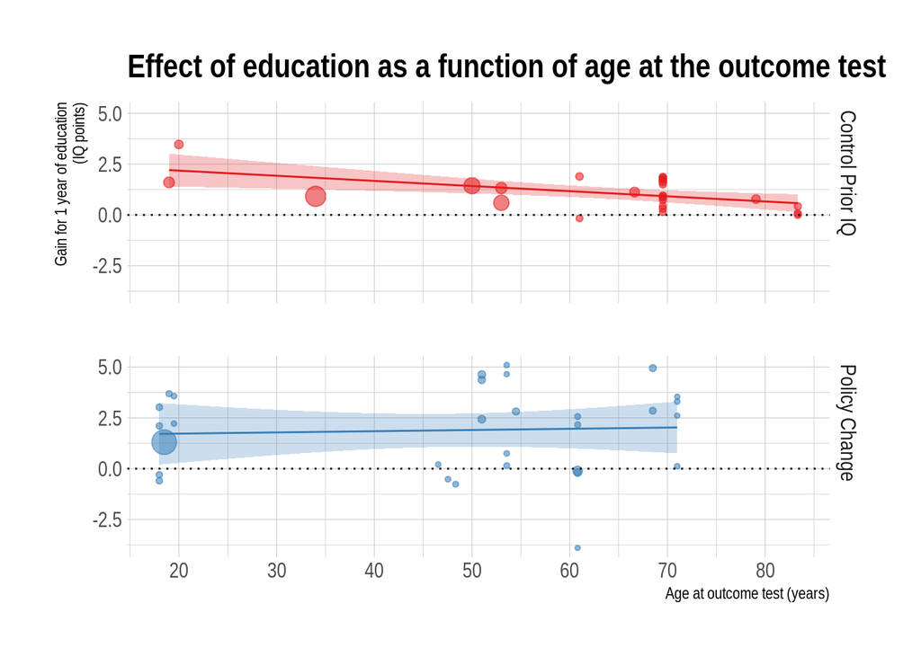

```r
library(hrbrthemes)
meta_2_gg +
  theme_ipsum()
```

## Сохранение данных

Функция `ggsave()` (аналог в базовом R - `save()`)

```r
plot <- ggplot(data=iris, aes(x=Sepal.Length, y=Sepal.Width)) +
  geom_point(aes(shape=Species, color=Species))


# setwd("/Users/olgaliashevskaia/Desktop")

ggsave("plot1.png")
ggsave(plot, file="plot2.png")
ggsave(plot, file="plot3.png", width=6, height=4)
```

## Пример №2: Vowel duration and intonation in Cantonese

Датасет `homo`: исследование связи между акустическим сигналом и восприятием гендерной ориентации говорящих (кантонский диалект китайского языка). В экспериментах использовался перцептивный тест и сбор суждений относительно 14 говорящих.

- [s] duration (s.duration.ms)
- vowel duration (vowel.duration.ms)
- fundamental frequencies mean (F0) (average.f0.Hz)
- fundamental frequencies range (f0.range.Hz)
- percentage of homosexual impression (perceived.as.homo)
- percentage of heterosexal impression (perceived.as.hetero)
- speakers orientation (orientation)
- speakers age (age)

```r
homo <- read_csv("https://raw.githubusercontent.com/LingData2019/LingData2020/master/data/orientation.csv")
head(homo)
```

```
## # A tibble: 6 × 10
##   speaker s.duration.ms vowel.duration.ms average.f0.Hz f0.range.Hz
##   <chr>           <dbl>             <dbl>         <dbl>       <dbl>
## 1 A                61.4             113.           120.        52.5
## 2 B                63.9             126.           100.       114
## 3 C                55.1             127.           115.       103.
## 4 D                78.1             119.           127.        58.8
## 5 E                64.7              93.7          131.        37.4
## 6 F                67               128.           151.        42
## # ℹ 5 more variables: perceived.as.homo <dbl>, perceived.as.hetero <dbl>,
## #   perceived.as.homo.percent <dbl>, orientation <chr>, age <dbl>
```

### Scatterplot

s.duration.ms vs. vowel.duration.ms

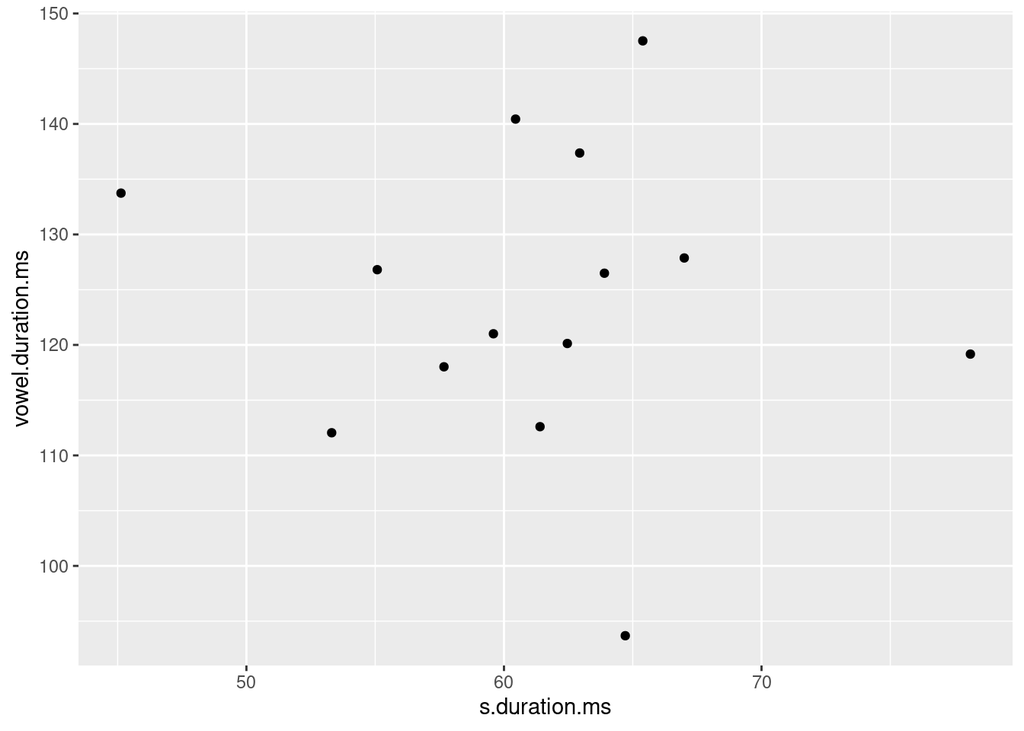

```r
homo |>
   ggplot(aes(s.duration.ms, vowel.duration.ms)) +
   geom_point()
```

### Scatterplot: color

Добавьте цвет по столбцу color = orientation

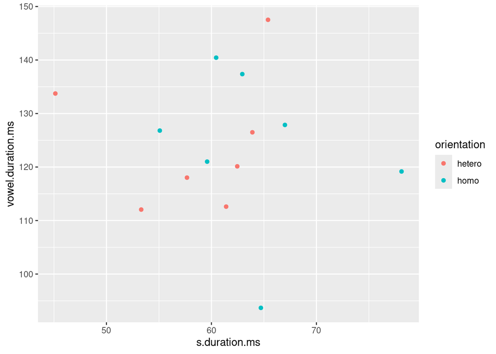

```r
homo |>
  ggplot(aes(s.duration.ms, vowel.duration.ms,
             color = orientation)) +
  geom_point()
```

### Scatterplot: shape

Вместо цвета shape

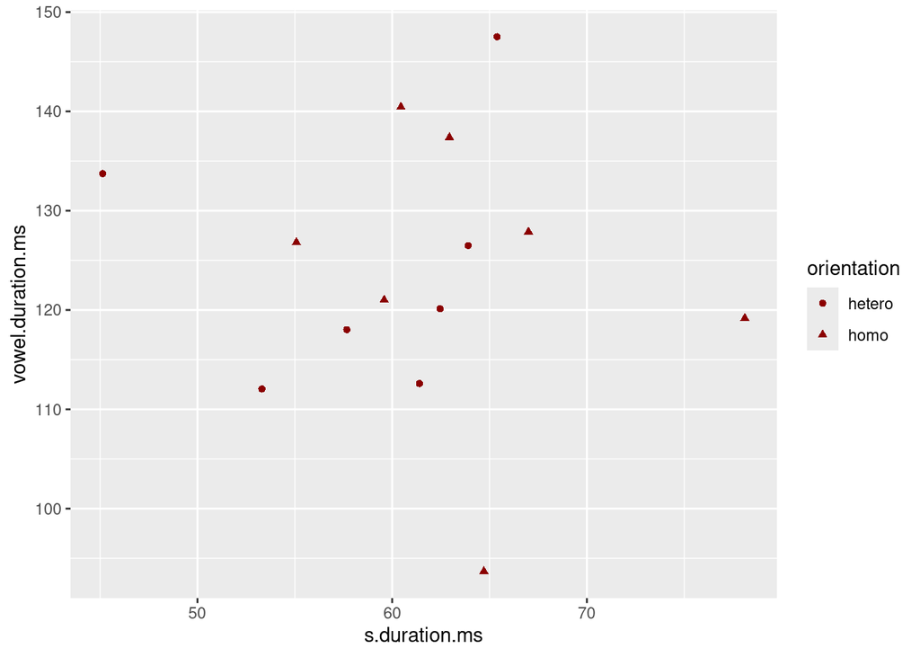

```r
homo |>
  ggplot(aes(s.duration.ms, vowel.duration.ms,
             shape = orientation)) +
  geom_point(color = "darkred")
```